# MSDS 6306 Homework 4

Chris Donlan

October 20, 2016

# Overview

The central limit theorem (CLT) states that, given certain conditions, the arithmetic mean of a sufficiently large number of iterates of independent random variables, each with a well-defined expected value and well-defined variance, will be approximately normally distributed, regardless of the underlying distribution

In this test, we will illistrate how the CLT works, by bootstrapping a small random sample of numbers. The first two samples, normalsample1 and normalsample2, were created using rnorm. The third and forth bootstrap, came from random sample from an exponential distribution pupulation by using rexp.

## Normal Distribution Sample 1

In this experiement, we will create a small sample of five number from a noramlly distributed population.

```r
Count<-1000
bootmean<- numeric(Count)
normalsample1 <- rnorm(5, mean = 0, sd = 10)
```

### Descriptive statistics and histogram for sample1

```r
#Mean for sample1
mean(normalsample1)
```

```
## [1] -0.316178
```

```r
#Standard Deviation for sample1
sd(normalsample1)
```

```
## [1] 13.76483
```

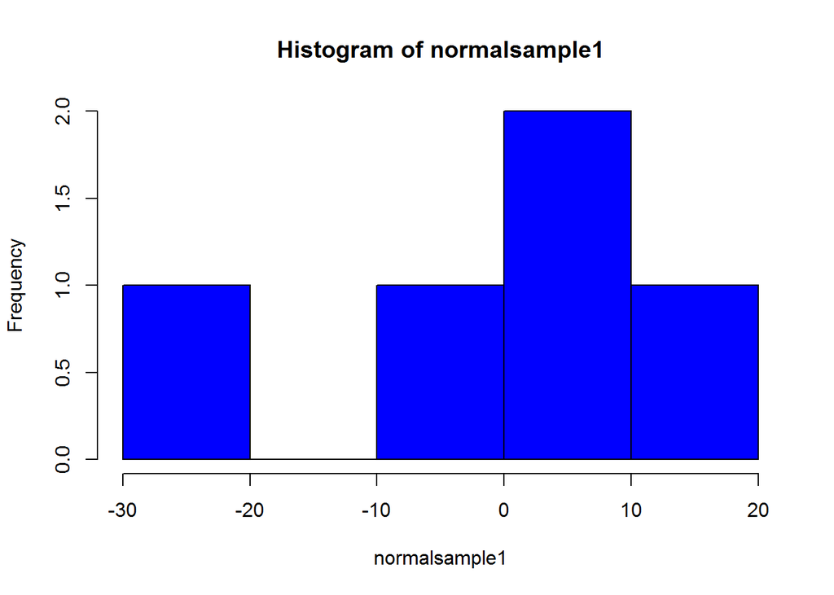

```r
#Histogram for sample1
hist(normalsample1, col="blue")
```

### Bootstrap sample1

Next, we take a sample of 50 numbers, from sample, 1000 times. We save the mean of each sample into a vector called bootmean.

```r
for(i in 1:Count) {
  bootsample <- sample(normalsample1, size=50, replace=TRUE)
  bootmean[i]<- mean(bootsample)
}
```

### Descriptive statistics and histogram for bootstrap sample1

We can see that the mean of the bootmean samples is very close to our original mean.

```r
sd(bootmean)
```

```
## [1] 1.814548
```

```r
mean(bootmean)
```

```
## [1] -0.2369664
```

We can see the means from bootstraping follow a normal distribution.

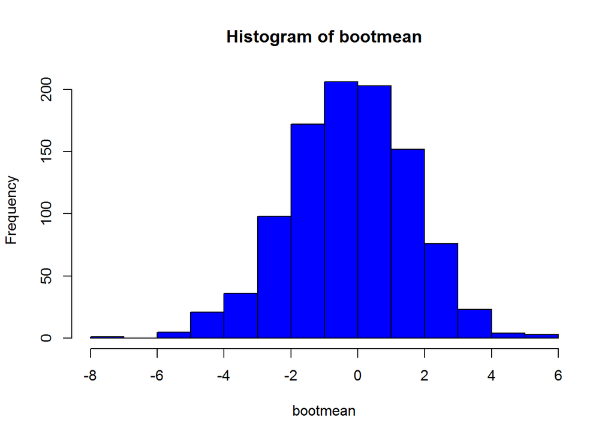

```r
hist(bootmean, col="blue")
```

## Normal Distribution Sample 2

Similar to normalsample1, but this random normal sample has a larger standard deviation.

```r
normalsample2 <- rnorm(8,mean=0, sd=100)
```

### Descriptive statistics and histogram for normalsample2

```r
mean(normalsample2)
```

```
## [1] 31.8338
```

```r
sd(normalsample2)
```

```
## [1] 110.3487
```

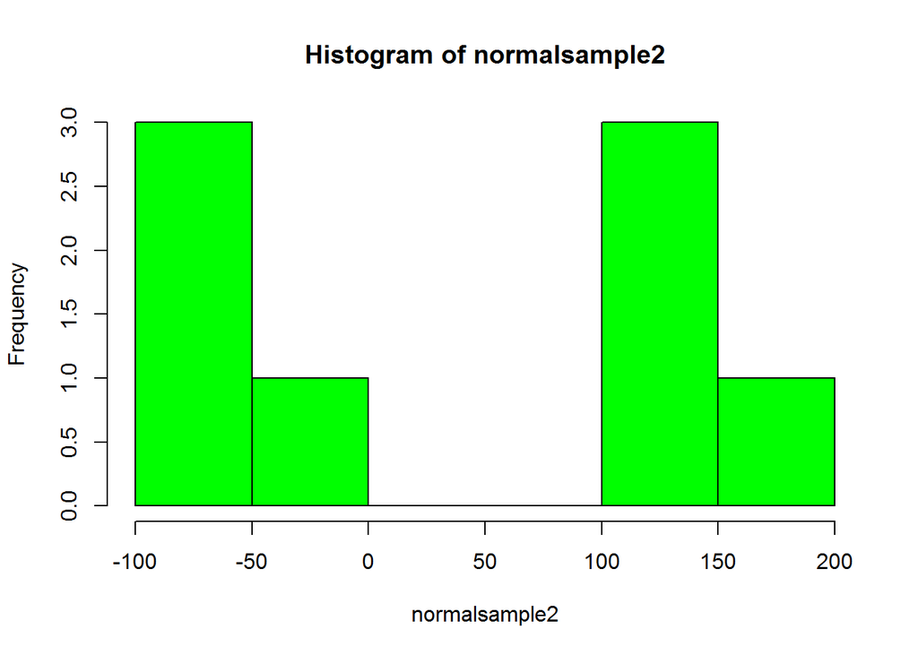

```r
hist(normalsample2, col="green")
```

Next, we take a sample of 50 numbers, from sample, 1000 times. We save the mean of each sample into a vector called bootmean.

```r
#Reset bootsample and bootmean
bootsample <-NULL
bootmean <- NULL

for(i in 1:Count) {
  bootsample <- sample(normalsample2, size=50, replace=TRUE)
  bootmean[i]<- mean(bootsample)
}
```

### Descriptive statistics and histogram for bootstrap normalsample2

```r
mean(bootmean)
```

```
## [1] 31.19387
```

```r
sd(bootmean)
```

```
## [1] 14.38735
```

We can see the means from bootstraping follow a normal distribution.

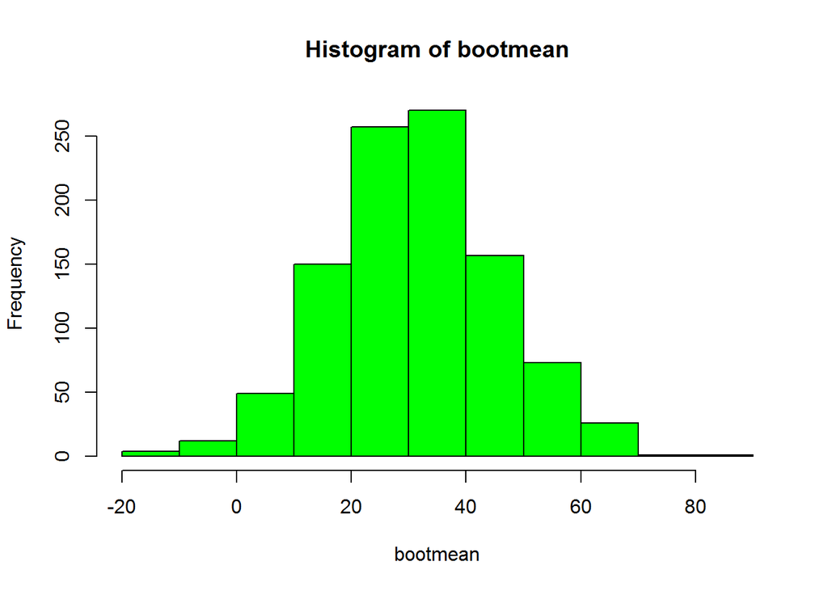

```r
hist(bootmean, col="green")
```

## Exponential Distribution Sample 1

In this experiement, we will create a small sample of five number from a exponential distributed.

```r
expsample1 <- rexp(5, rate = 1)
```

### Descriptive statistics and histogram for expsample1

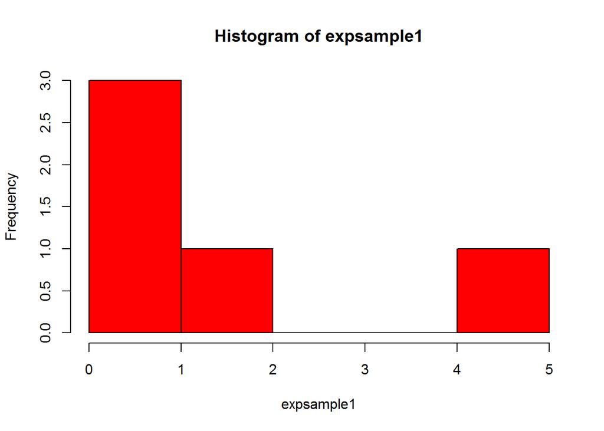

```r
hist(expsample1, col="red")
```

```r
mean(expsample1)
```

```
## [1] 1.485575
```

```r
sd(expsample1)
```

```
## [1] 1.736361
```

Next, we take a sample of 50 numbers, from sample, 1000 times. We save the mean of each sample into a vector called bootmean.

```r
bootsample <-NULL
bootmean <- NULL

for(i in 1:Count) {
  bootsample <- sample(expsample1, size=50, replace=TRUE)
  bootmean[i]<- mean(bootsample)
}
```

### Descriptive statistics and histogram for bootstrap mean of expsample1

```r
mean(bootmean)
```

```
## [1] 1.488177
```

```r
sd(bootmean)
```

```
## [1] 0.2306208
```

We can see the means from bootstraping follow a normal distribution.

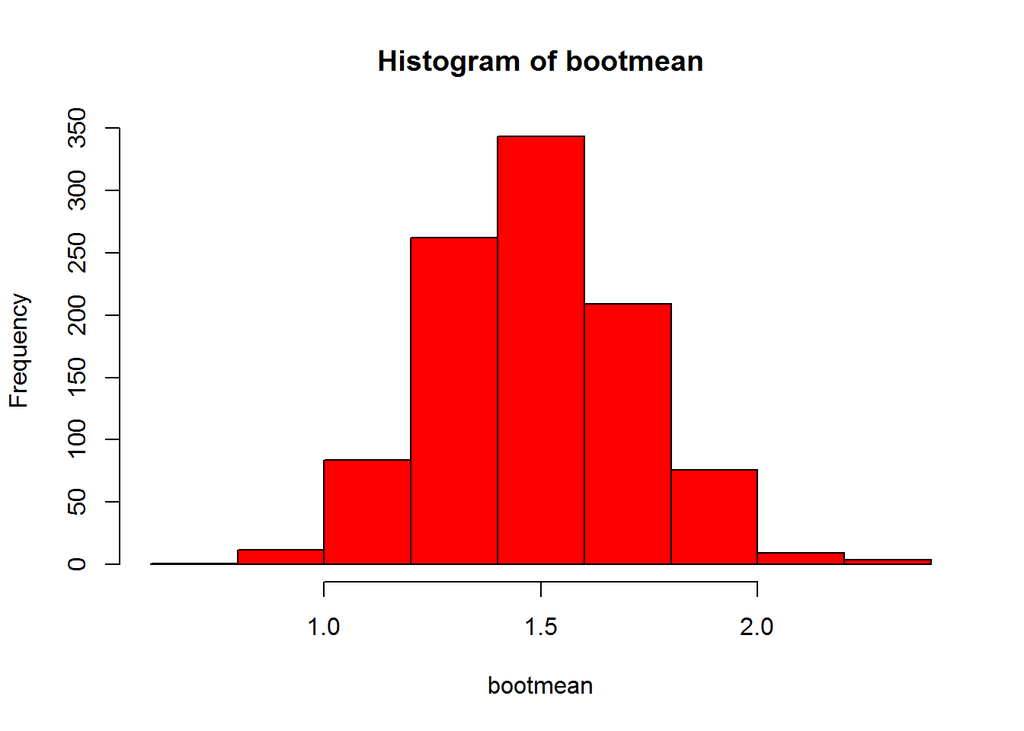

```r
hist(bootmean, col="red")
```

## Exponential Distribution Sample 2

In this experiement, we will create a small sample of five number from a exponential distributed, with a rate of 2.

```r
expsample2 <- rexp(5, rate = 2)
```

### Descriptive statistics and histogram for expsample2

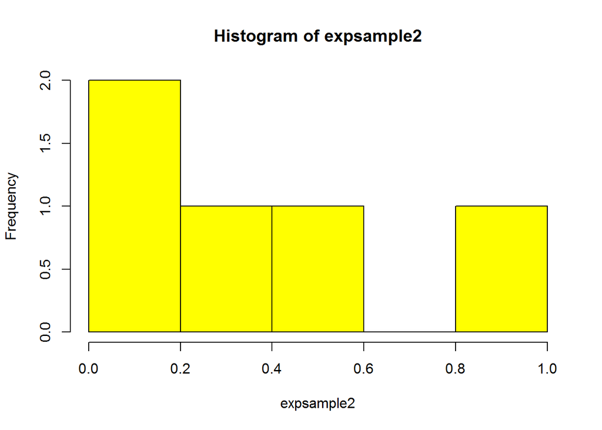

```r
hist(expsample2, col="yellow")
```

```r
mean(expsample2)
```

```
## [1] 0.3348726
```

```r
sd(expsample2)
```

```
## [1] 0.3225961
```

Next, we take a sample of 50 numbers, from sample, 1000 times. We save the mean of each sample into a vector called bootmean.

```r
bootsample <-NULL
bootmean <- NULL

for(i in 1:Count) {
  bootsample <- sample(expsample2, size=50, replace=TRUE)
  bootmean[i]<- mean(bootsample)
}
```

### Descriptive statistics and histogram for bootstrap mean of expsample2

```r
mean(bootmean)
```

```
## [1] 0.3344723
```

```r
sd(bootmean)
```

```
## [1] 0.03999837
```

We can see the means from bootstraping follow a normal distribution.

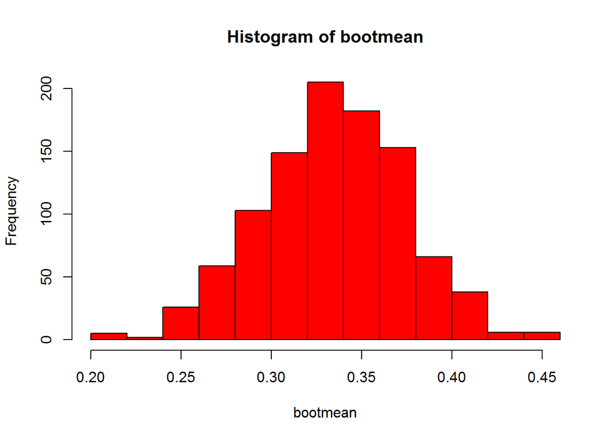

```r
hist(bootmean, col="red")
```